# homoscedasticity

## Assessing the Linear Modelling Assumption of Homoscedasticity

*Julia Piaskowski*

*March 3, 2026*

### “Residuals were inspected for normality and common variance visually using Q–Q plots and plots of residuals versus predicted values.”

## Linear Model Review

$$Y_i = \beta_0 + \beta_1 X_i + \epsilon_i$$

$Y_i$ = dependent variable (there is only 1)

$X_i$ = independent variable(s) (there may be many)

$B_0$ = model intercept, the overall mean of $Y$

$B_1$ = how $Y$ changes with $X$

$\epsilon_i$ = model residual, the gap between the predicted value for $Y_i$ and its observed value

## The Residual Is Important

$$\epsilon_i \sim N(0, \sigma)$$

- The residuals are normally distributed with a mean of zero and some standard deviation that we will estimate during the model-fitting process.
- All model residuals are *independent and identically distributed*, “i.i.d.” – they are uncorrelated with each other and drawn from the same distribution (that has exactly one variance)

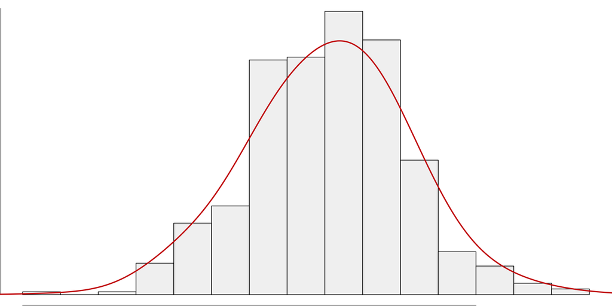

## More on iid

- For every observation, there is a residual: $\{n_1, n_2,...,n_j\}$, $\{e_1, e_2,...,e_j\}$
- imagine we have a data set of 3 observations and hence 3 residuals: $\{e_1, e_2, e_3\}$
- there is a variance-covariance matrix for the residuals:

$$\epsilon_i \sim N (0,
\begin{bmatrix}
\sigma & 0 & 0 \\
0 & \sigma & 0 \\
0 & 0 & \sigma
\end{bmatrix} )$$

- all diagonal elements share a common variance (identical distribution), the off-diagonals are zero (independently distributed)

## Why is iid Important?

- ANOVA F-tests rely on this
- The standard errors of the estimates and pairwise comparisons rely on this assumption
- unequal error violations can result in higher type I error rate (false positives)
- independence violations can results in a higher type II error rate (false negatives)

## Example Analysis 1: Assumptions Met

- White pine study, 4 pollen parents crossed with 7 female trees (4 reps), epicotyl length was assessed

```r
data("hanover.whitepine", package = "agridat")
hist(hanover.whitepine$length, main = NULL, xlab = "epicotyl length", cex.lab = cex_lab, col = "#65B362")
```

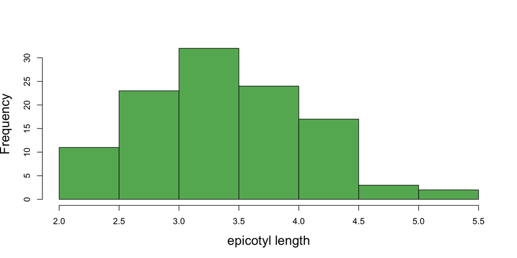

## Example Analysis 1: Assumptions Met

```r
library(lme4)
m1 <- lmer(length ~ male*female + (1|rep), data = hanover.whitepine)
plot(m1, xlab = "predicted values", ylab = "Pearson residuals",  main = "Standard Residual Plot")
```

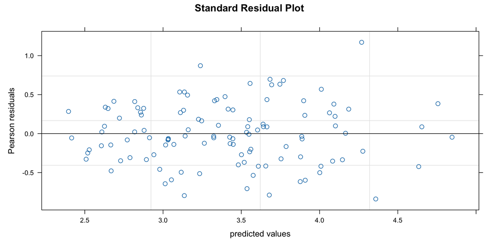

## Example Analysis 1: Assumptions Met

```r
plot(rstudent(m1), col = "blue3", main = "Plot by Data Set Order", ylab = "studentized residuals", xlab = "spreadsheet row"); abline(h = 0)
```

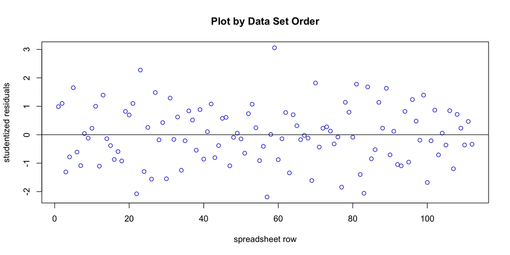

## Example Analysis 1: Assumptions Met

```r
plot(m1, resid(., scaled=TRUE) ~fitted(.) | rep, xlab = "predicted values", ylab = "Pearson residuals",  main = "Standard Residual Plot by Rep", abline = 0)
```

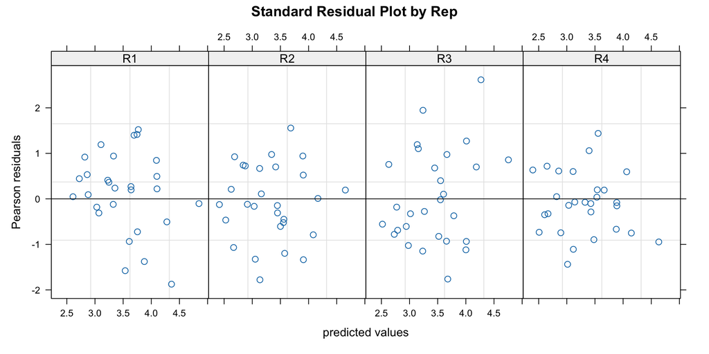

## Example Analysis 1: Assumptions Met

```r
plot(m1, male ~ resid(.,type = "response", scaled=TRUE), main = "Residuals by a Variable", xlab = "standardized Residuals")
```

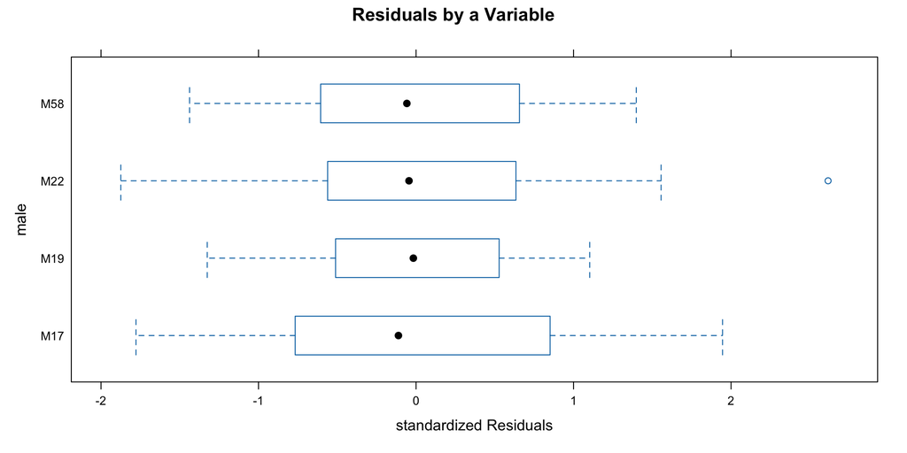

## Example Analysis 1: Assumptions Met

```r
plot(m1, female ~ resid(.,type = "response", scaled=TRUE), main = "Residuals by a Variable", xlab = "standardized Residuals")
```

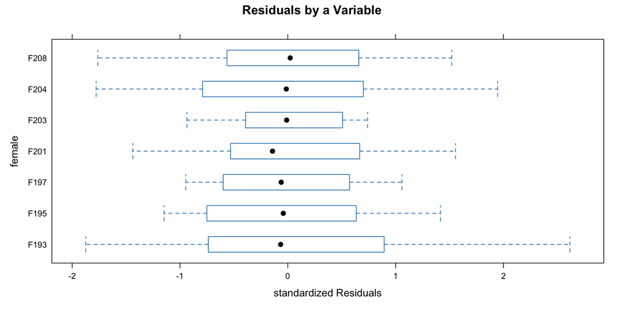

# What if the iid assumptions are not met?

In the “general” linear model days, when a premium was placed on the i.i.d. error paradigm, if we did reject $H_0$, it would set off a minor crisis in the form of a hunt for a variance stabilizing transformation. In contemporary modeling, we simply proceed with inference on estimable functions using the unequal variance model.

– Walt Stroup, Marina Ptukhiuna and Julie Garai (2024), *[Generalized Linear Mixed Models](https://www.taylorfrancis.com/books/mono/10.1201/9780429092060/generalized-linear-mixed-models-walter-stroup-marina-ptukhina-julie-garai)*, 2nd Ed, Section 7.2.3.1

## Assumptions Not Met

#### *Heteroscedasticity [1]*

- When an independent factor in the study is causing heteroscedasticity
- multi-environment agronomic study: 38 plant varieties, 9 locations, 4 reps each (RCBD)

```r
var_ex1 <- read.csv(here::here("static", "tutorials", "data", "MET_trial_variance.csv")) |>
  mutate(block = as.character(block))
head(var_ex1, n = 4)
```

```
    site block    variety    yield
1 site_7     4 variety_23       NA
2 site_7     1 variety_22 2.881003
3 site_7     2 variety_23 4.321505
4 site_7     4  variety_3 4.321505
```

## Assumptions Not Met

#### *Heteroscedasticity [1]*

```r
hist(var_ex1$yield, main=NA, col = "orange", ylab=NULL, xlab = "seed yield", cex.lab = cex_lab, cex.axis = cex_axis, breaks = 15)
```

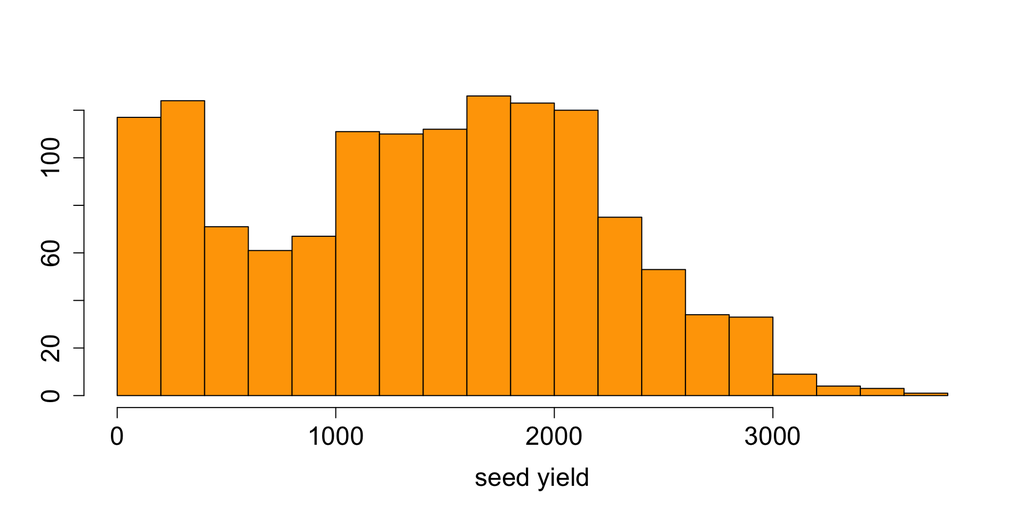

## Assumptions Not Met

#### *Heteroscedasticity [1]*

```r
boxplot(yield ~ site, data = var_ex1, col = "orange", xlab = "location")
```

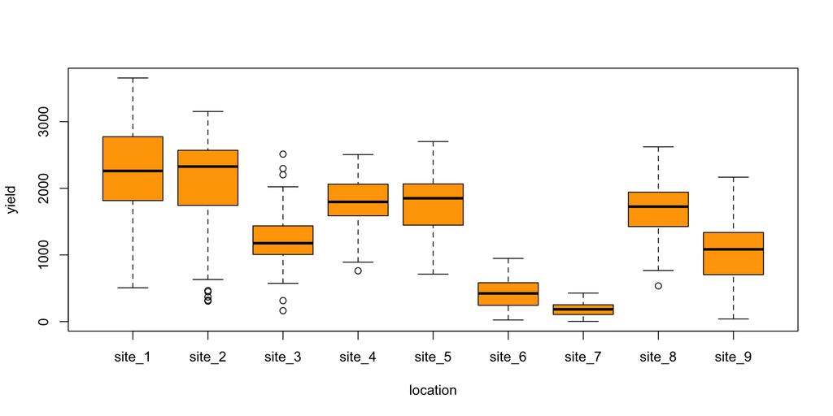

## Assumptions Not Met

#### *Heteroscedasticity [1]*

```r
library(nlme)
m2 <- lme(yield ~ site:variety + variety, random = ~ 1 |site/block,
          na.action = na.exclude, data = var_ex1)
plot(m2)
```

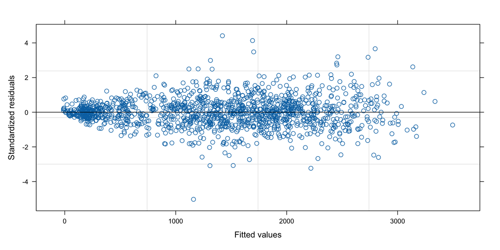

## Assumptions Not Met

#### *Heteroscedasticity [1]*

```r
plot(m2, site  ~ resid(.,type = "response", scaled=TRUE))
```

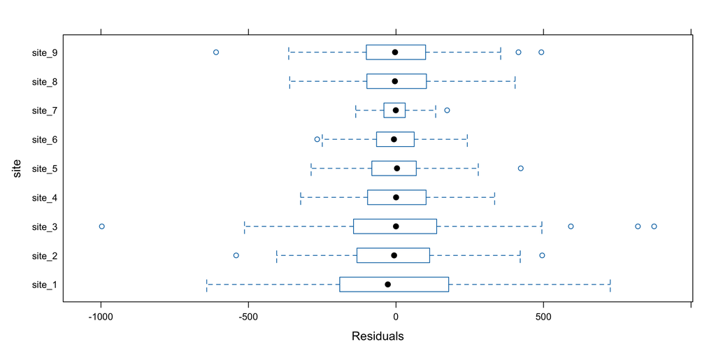

## Assumptions Not Met

#### *Heteroscedasticity [1]*

*Solution:* model variance for each site with `varIdent()`, an ‘nlme’ function

```r
m2_new <- lme(yield ~ site:variety + variety, random = ~ 1 |site/block,
              na.action = na.exclude, data = var_ex1,
              weights = varIdent(form = ~1|site))
plot(m2_new)
```

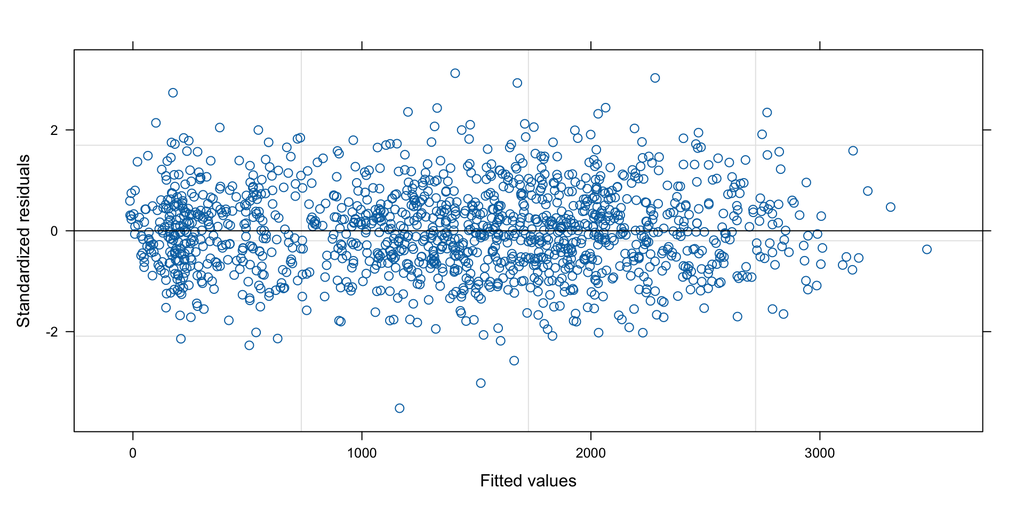

## Assumptions Not Met

#### *Heteroscedasticity [1]*

```r
library(emmeans)
emmeans(m2, ~ variety*site, at = list(variety = "variety_1", site = c("site_1", "site_8", "site_7")))
```

```
 variety   site   emmean  SE df lower.CL upper.CL
 variety_1 site_1   1713 126  8     1423     2002
 variety_1 site_8   1327 126  8     1038     1617
 variety_1 site_7    147 126  8     -142      437

Degrees-of-freedom method: containment
Confidence level used: 0.95
```

```r
emmeans(m2_new, ~ variety*site, at = list(variety = "variety_1", site = c("site_1", "site_8", "site_7")))
```

```
 variety   site   emmean    SE df lower.CL upper.CL
 variety_1 site_1   1713 186.0  8   1283.8     2142
 variety_1 site_8   1327 124.0  8   1040.6     1614
 variety_1 site_7    147  98.8  8    -80.5      375

Degrees-of-freedom method: containment
Confidence level used: 0.95
```

## Assumptions Not Met

#### *Heteroscedasticity [1]*

```r
anova(m2, type = "marginal")
```

```
             numDF denDF   F-value p-value
(Intercept)      1   977 185.95512  <.0001
variety         37   977  28.28370  <.0001
site:variety   304   977   7.80575  <.0001
```

```r
anova(m2_new, type = "marginal")
```

```
             numDF denDF  F-value p-value
(Intercept)      1   977 84.79352  <.0001
variety         37   977 10.75473  <.0001
site:variety   304   977 10.19020  <.0001
```

## Assumptions Not Met

#### *Heteroscedasticity [2]*

- When the mean and variance are linked
- single agronomic study: 38 plant varieties evaluated in one trial, 4 reps each (RCBD)

```r
var_ex2 <- read.csv(here::here("static", "tutorials", "data", "single_trial_variance.csv")) |>
  dplyr::mutate(block = as.character(block))

head(var_ex2, n = 4)
```

```
  block    variety    yield
1     1  variety_1 127.4420
2     1 variety_10 528.7488
3     1 variety_11 409.4414
4     1 variety_12 173.5381
```

## Assumptions Not Met

#### *Heteroscedasticity [2]*

```r
hist(var_ex2$yield, col = "#F88379", main = NULL, xlab = "seed yield",  cex.lab = cex_lab, cex.axis = cex_axis)
```

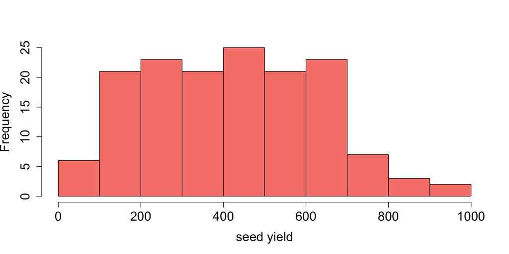

## Assumptions Not Met

#### *Heteroscedasticity [2]*

```r
m3 <- lme(yield ~ variety, random = ~ 1 |block,
          na.action = na.exclude, data = var_ex2)
plot(m3, main = "Classic Funnel Shape", abline = 0)
```

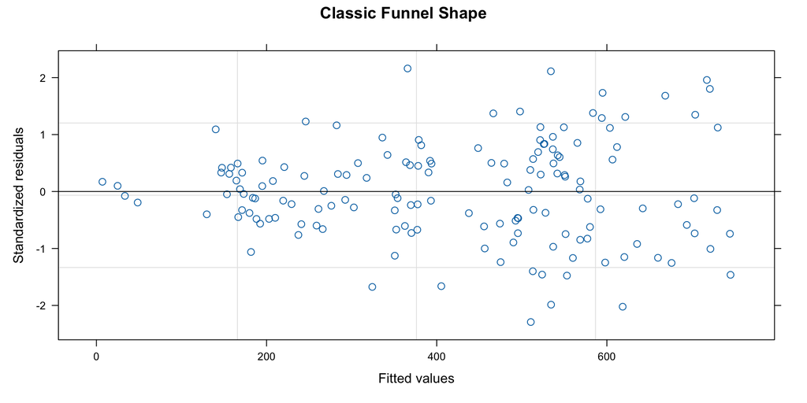

## Assumptions Not Met

#### *Heteroscedasticity [2]*

*Solution:* model variance as a function of the model fitted values using `varPower()`, an ‘nlme’ function

```r
m3_new <- lme(yield ~ variety, random = ~ 1 |block, na.action = na.exclude, data = var_ex2,
              weights = varPower())
plot(m3_new)
```

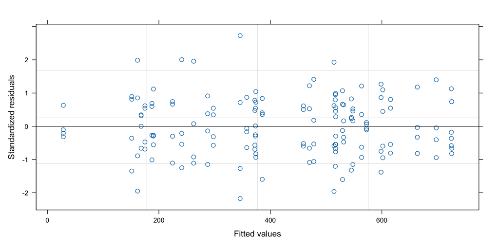

## Assumptions Not Met

#### *Heteroscedasticity [2]*

```r
emmeans(m3, ~ variety, at = list(variety = c("variety_22", "variety_3", "variety_26")))
```

```
 variety    emmean   SE df lower.CL upper.CL
 variety_22   28.5 59.8  3   -161.9      219
 variety_3   168.1 59.8  3    -22.3      359
 variety_26  725.3 59.8  3    534.9      916

Degrees-of-freedom method: containment
Confidence level used: 0.95
```

```r
emmeans(m3_new, ~ variety, at = list(variety = c("variety_22", "variety_3", "variety_26")))
```

```
 variety    emmean    SE df lower.CL upper.CL
 variety_22   28.5  6.43  3      8.0     48.9
 variety_3   168.1 27.70  3     79.9    256.3
 variety_26  725.3 92.30  3    431.5   1019.1

Degrees-of-freedom method: containment
Confidence level used: 0.95
```

## Assumptions Not Met

#### *Heteroscedasticity [2]*

```r
anova(m3, type = "marginal")
```

```
            numDF denDF F-value p-value
(Intercept)     1   111 33.3863  <.0001
variety        37   111  9.6935  <.0001
```

```r
anova(m3_new, type = "marginal")
```

```
            numDF denDF  F-value p-value
(Intercept)     1   111 47.47258  <.0001
variety        37   111 29.91473  <.0001
```

*Note*: LSD (least significant difference) calculations rely on a single variance term, so LSD cannot be used on these models (and is ill defined for mixed models)

## Hypothesis Testing

- Tests for unequal variance by groups
  - Bartlett’s test: `bartlett.test()`
  - Levene’s test: `car::leveneTest(..., center = "mean")`
  - Brown-Forsythe test: `car::leveneTest(..., center = "median")`
- Test for unequal variance for regression: `lmtest::bptest()`
- Log likelihood ratio tests between models 🤩

## Hypothesis Testing

- Barlett’s test for unequal variance ($H_0$: group variances are equal)

```r
bartlett.test(yield ~ site, data = var_ex1)
```

```
    Bartlett test of homogeneity of variances

data:  yield by site
Bartlett's K-squared = 567.26, df = 8, p-value < 2.2e-16
```

## Hypothesis Testing

- Log likelihood ratio test ($H_0$: the models are equivalent)  
- “Better” model: lower AIC, lower BIC, higher log likelihood  
- Test to determine if change in log likelihood is meaningful

```r
anova(m2, m2_new)
```

```
       Model  df      AIC      BIC    logLik   Test  L.Ratio p-value
m2         1 345 14814.25 16511.55 -7062.128
m2_new     2 353 14489.23 16225.88 -6891.615 1 vs 2 341.0259  <.0001
```

## SAS Options

#### *For evaluating homoscedasticity*

```sas
proc glm data=var_ex1;
  class site variety rep;
  model yield = variety|site rep(site);
  means site / hovtest=bartlett bf levene;
run;
```

[Proc GLM Documentation](https://documentation.sas.com/doc/en/pgmsascdc/9.4_3.5/statug/statug_glm_syntax15.htm#statug.glm.means_opt_hov)

## SAS Options

#### *For modelling heteroscedasticity*

```sas
proc mixed data=var_ex1;
  class site variety rep;
  model yield = site*variety + variety;
  random rep(site);
  repeated / group = site;
run;
```

[Proc Mixed Documentation](https://go.documentation.sas.com/doc/en/pgmsascdc/9.4_3.4/statug/statug_mixed_syntax14.htm)

# Intractable iid Violations

## Lognormal Models

*Almost normal, just take the (natural) log*

Earthquake acceleration

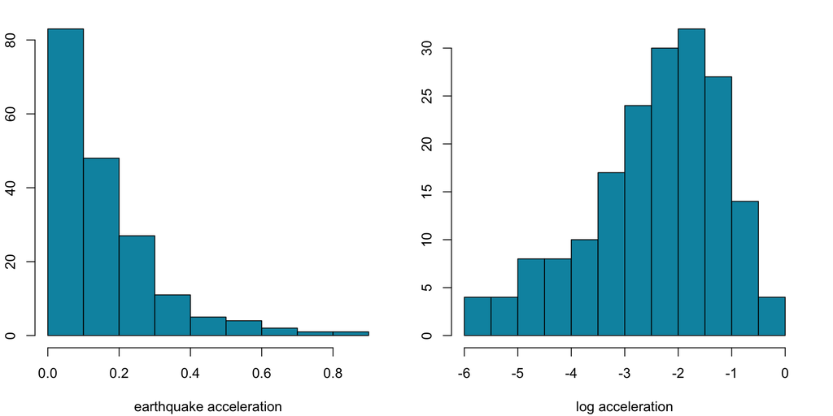

## Lognormal Models

```r
m4 <- gls(accel ~ Quake, data = Earthquake)
plot(m4, abline = 0)
```

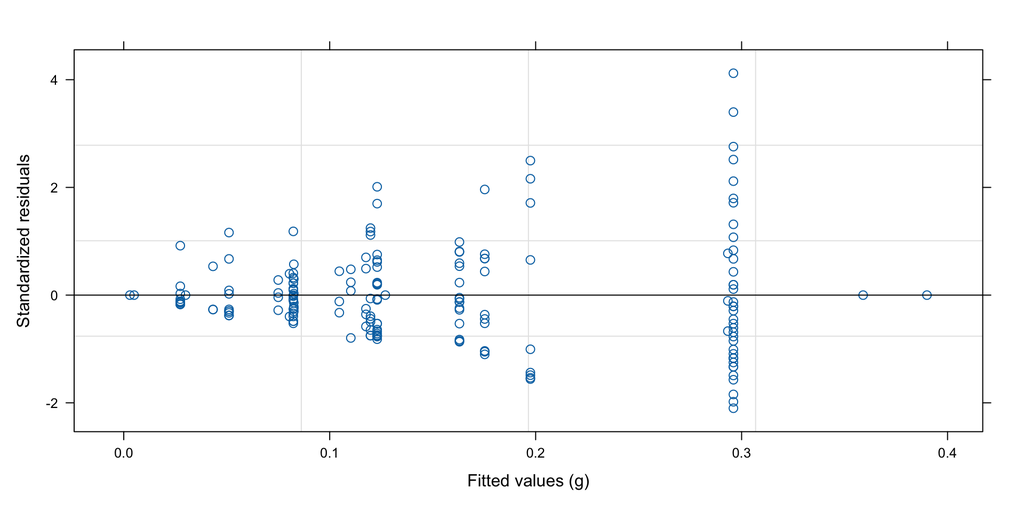

## Lognormal Models

```r
m4_new <- gls(log(accel) ~ Quake, data = Earthquake)
plot(m4_new, abline = 0)
```

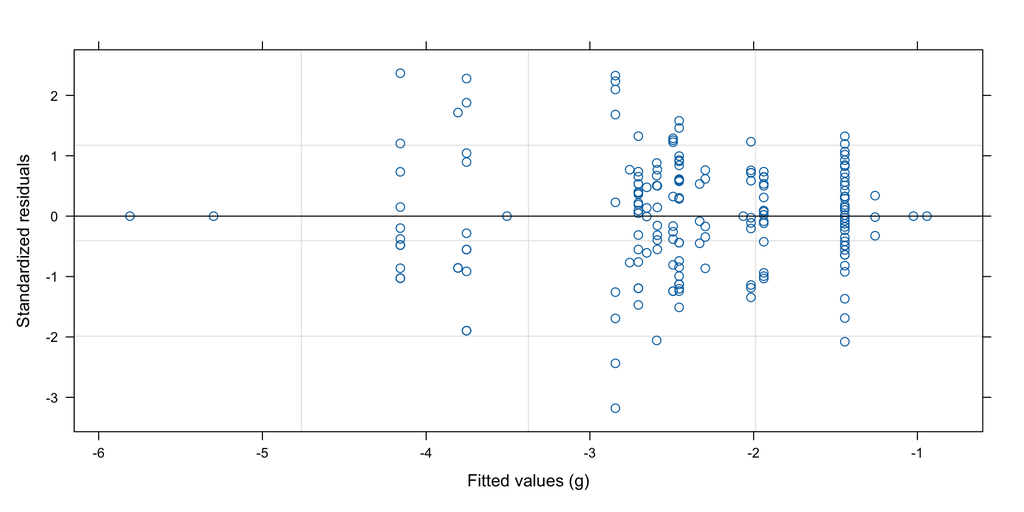

## Lognormal Models

```r
anova(m4)
```

```
Denom. DF: 159
            numDF   F-value p-value
(Intercept)     1 278.13410  <.0001
Quake          22   4.50921  <.0001
```

```r
anova(m4_new)
```

```
Denom. DF: 159
            numDF   F-value p-value
(Intercept)     1 1232.4445  <.0001
Quake          22    6.8964  <.0001
```

## Lognormal Models

```r
emmeans(m4, "Quake", at = list(Quake = c("20", "10", "5")))
```

```
 Quake emmean     SE  df lower.CL upper.CL
 20    0.1630 0.0312 159   0.1014    0.225
 10    0.0300 0.1250 159  -0.2164    0.276
 5     0.0275 0.0376 159  -0.0468    0.102

Degrees-of-freedom method: df.error
Confidence level used: 0.95
```

```r
emmeans(m4_new, "Quake", type = "response", at = list(Quake = c("20", "10", "5")))
```

```
 Quake response     SE  df lower.CL upper.CL
 20      0.1439 0.0335 159  0.09086   0.2281
 10      0.0300 0.0280 159  0.00476   0.1890
 5       0.0156 0.0044 159  0.00898   0.0272

Degrees-of-freedom method: df.error
Confidence level used: 0.95
Intervals are back-transformed from the log scale
```

## Other Generalized Models

- Poisson: the mean equals the variance
- negative binomial, binomial (logistic), gamma, geometric, beta, …(more): the variance is a mathematical function of the mean
- common deviations: count data (unless even the lowest counts are very high), percent data that might be subject to bounding of the values, binomial outcomes, multinomial outcomes, highly skewed data
- A generalized linear model is needed; these use another distribution to describe the behavior of a dependent variable (not the residuals). Learning these could constitute a semester-long course.

## Final Thoughts

- In standard linear models, there is an ‘iid’ assumption (independent and identically distributed): we assume that model residuals shares a single common variance and are uncorrelated with each other
- Violating these assumptions can impact the power of hypothesis testing and the width of confidence intervals
- Failure to address these violations invalidates the analysis and inference from it
- We can model variance by categorical variable or by a covariate using tools in the R package ‘nlme’
- Some variables by their nature violate the iid assumption and required generalized linear models to analyze

## Additional Resources

- [Heteroscedasticity Examples](https://idahoagstats.github.io/mixed-models-in-R/chapters/variance-components.html#variance-estimation-under-heteroscedasticity): more details on the data and analysis
- [*Mixed-Effects Models in S and S-PLUS*](https://link.springer.com/book/10.1007/b98882) *thee book* for **nlme**, by José C. Pinheiro and Douglas M. Bates (2000). We used this book extensively for developing this guide. Sadly, it’s out of print. However, there are affordable used copies available; some school libraries also carry this.
- [Zero Inflated Models and Generalized Linear Mixed Models with R](https://www.highstat.com/index.php/books2?view=article&id=19&catid=18) (2012) by Alain Zuur, Anatoly Saveliev, and Elena Ieno
- [GLMM FAQs](https://bbolker.github.io/mixedmodels-misc/glmmFAQ.html) by Ben Bolker ([more resources](https://bbolker.github.io/mixedmodels-misc/) on mixed models from Dr. Bolker)